# R Notebook

## Introduction

#### **Background**

There is a high risk of landing overrun if the aircraft’s landing distance exceeds the available distance. The landing distance required is affected by many factors. We use the simulated data provided by Professor Dr. Liu to study the factors involved and how they would impact the landing distance of a commercial flight.

#### **Motivation**

To reduce landing overrun

#### **Goal**

To study what factors and how they would impact the landing distance of a commercial flight

#### **Steps Followed**

1. Understanding and importing the data
2. Merging the data
3. Removing the duplicates and abnormal values
4. Handling missing values
5. Correlation analysis with respect to the target feature
6. Identifying the significant parameters
7. Fitting a linear regression model to the get the relationship between independent variables and target feature
8. Model Diagonistic and Re fitting

#### **Libraries**

```r
library(tidyverse)
library(readxl)
```

## Data Preparation

#### **Collection of Data**

The data has been simulated from statistical models. It is provided in two excel sheets with a total of 950 records of commercial flight observations - the landing distance and other parameters.

#### **Data Description**

The data is provided in two excel files:

1. FAA2.xls : Excel file has 800 records and 8 columns. Column names : aircraft , duration, no_pasg, speed_ground, speed_air, height, pitch,
2. FAA2.xls : Excel file has 150 records and 7 columns. Column names: aircraft , no_pasg, speed_ground, speed_air, height, pitch, distance.

**Column description**

- Aircraft: The make of an aircraft (Boeing or Airbus).
- Duration: Flight duration between taking off and landing. The duration of a normal flight should always be greater than 40min.
- No_pasg : The number of passengers in a flight.
- Speed_ground (in miles per hour): The ground speed of an aircraft when passing over the threshold of the runway. If its value is less than 30MPH or greater than 140MPH, then the landing would be considered as abnormal.
- Speed_air (in miles per hour): The air speed of an aircraft when passing over the threshold of the runway. If its value is less than 30MPH or greater than 140MPH, then the landing would be considered as abnormal.
- Height (in meters): The height of an aircraft when it is passing over the threshold of the runway. The landing aircraft is required to be at least 6 meters high at the threshold of the runway.
- Pitch (in degrees): Pitch angle of an aircraft when it is passing over the threshold of the runway.
- Distance (in feet): The landing distance of an aircraft. More specifically, it refers to the distance between the threshold of the runway and the point where the aircraft can be fully stopped. The length of the airport runway is typically less than 6000 feet.

#### **Importing the data**

```r
FAA1 <- read_excel("./FAA1(1).xls")
FAA2 <- read_excel("Data2.xlsx")
FAA1<-data.frame(FAA1)
FAA2<-data.frame(FAA2)
summary(FAA1)
```

```
##    aircraft            duration         no_pasg       speed_ground
##  Length:800         Min.   : 14.76   Min.   :29.00   Min.   : 27.74
##  Class :character   1st Qu.:119.49   1st Qu.:55.00   1st Qu.: 65.87
##  Mode  :character   Median :153.95   Median :60.00   Median : 79.64
##                     Mean   :154.01   Mean   :60.13   Mean   : 79.54
##                     3rd Qu.:188.91   3rd Qu.:65.00   3rd Qu.: 92.33
##                     Max.   :305.62   Max.   :87.00   Max.   :141.22
##
##    speed_air          height           pitch          distance
##  Min.   : 90.00   Min.   :-3.546   Min.   :2.284   Min.   :  34.08
##  1st Qu.: 96.16   1st Qu.:23.338   1st Qu.:3.658   1st Qu.: 900.95
##  Median :100.99   Median :30.147   Median :4.020   Median :1267.44
##  Mean   :103.83   Mean   :30.122   Mean   :4.018   Mean   :1544.52
##  3rd Qu.:109.48   3rd Qu.:36.981   3rd Qu.:4.388   3rd Qu.:1960.44
##  Max.   :141.72   Max.   :59.946   Max.   :5.927   Max.   :6533.05
##  NA's   :600
```

```r
summary(FAA2)
```

```
##    aircraft         duration          no_pasg       speed_ground
##  Length:150         Mode:logical   Min.   :44.00   Min.   : 29.23
##  Class :character   NA's:150       1st Qu.:55.00   1st Qu.: 63.10
##  Mode  :character                  Median :60.50   Median : 76.53
##                                    Mean   :60.34   Mean   : 77.92
##                                    3rd Qu.:65.75   3rd Qu.: 91.54
##                                    Max.   :78.00   Max.   :141.22
##
##    speed_air          height           pitch          distance
##  Min.   : 90.11   Min.   :-3.546   Min.   :2.669   Min.   : 425.9
##  1st Qu.: 94.77   1st Qu.:22.910   1st Qu.:3.690   1st Qu.: 873.8
##  Median :100.26   Median :29.260   Median :3.988   Median :1272.0
##  Mean   :103.22   Mean   :30.233   Mean   :4.024   Mean   :1571.8
##  3rd Qu.:109.36   3rd Qu.:37.652   3rd Qu.:4.386   3rd Qu.:1993.5
##  Max.   :141.72   Max.   :58.084   Max.   :5.556   Max.   :6533.0
##  NA's   :111
```

#### **Data Cleaning**

We will be performing the following steps here: * We begin by combining the two datasets. * Removing the duplicates and abnormal values * Explore the data parameters. * Report the total sample size of training data. The data was acquired in two files FAA1.xls and FAA2.xls which were imported in FAA1 and FAA2 dataset respectively

#### **Merging Datasets**

```r
data <- rbind(FAA1, FAA2)
summary(data)
```

```
##    aircraft            duration         no_pasg       speed_ground
##  Length:950         Min.   : 14.76   Min.   :29.00   Min.   : 27.74
##  Class :character   1st Qu.:119.49   1st Qu.:55.00   1st Qu.: 65.52
##  Mode  :character   Median :153.95   Median :60.00   Median : 79.41
##                     Mean   :154.01   Mean   :60.17   Mean   : 79.28
##                     3rd Qu.:188.91   3rd Qu.:65.00   3rd Qu.: 92.13
##                     Max.   :305.62   Max.   :87.00   Max.   :141.22
##                     NA's   :150
##    speed_air          height           pitch          distance
##  Min.   : 90.00   Min.   :-3.546   Min.   :2.284   Min.   :  34.08
##  1st Qu.: 96.06   1st Qu.:23.302   1st Qu.:3.664   1st Qu.: 897.01
##  Median :100.89   Median :29.904   Median :4.015   Median :1267.44
##  Mean   :103.73   Mean   :30.139   Mean   :4.019   Mean   :1548.82
##  3rd Qu.:109.42   3rd Qu.:37.025   3rd Qu.:4.388   3rd Qu.:1965.64
##  Max.   :141.72   Max.   :59.946   Max.   :5.927   Max.   :6533.05
##  NA's   :711
```

#### **Removing the duplicates**

```r
data<-data[!duplicated(data[,c(1,3,5,8)]),]
```

The merged Dataset after removing duplicates: data: The final datasets after removing duplicate rows has a total 850 records and 8 columns. We need to check and handle the abnormal values from the dataset

```r
summary(data)
```

```
##    aircraft            duration         no_pasg      speed_ground
##  Length:850         Min.   : 14.76   Min.   :29.0   Min.   : 27.74
##  Class :character   1st Qu.:119.49   1st Qu.:55.0   1st Qu.: 65.90
##  Mode  :character   Median :153.95   Median :60.0   Median : 79.64
##                     Mean   :154.01   Mean   :60.1   Mean   : 79.45
##                     3rd Qu.:188.91   3rd Qu.:65.0   3rd Qu.: 92.06
##                     Max.   :305.62   Max.   :87.0   Max.   :141.22
##                     NA's   :50
##    speed_air          height           pitch          distance
##  Min.   : 90.00   Min.   :-3.546   Min.   :2.284   Min.   :  34.08
##  1st Qu.: 96.25   1st Qu.:23.314   1st Qu.:3.642   1st Qu.: 883.79
##  Median :101.15   Median :30.093   Median :4.008   Median :1258.09
##  Mean   :103.80   Mean   :30.144   Mean   :4.009   Mean   :1526.02
##  3rd Qu.:109.40   3rd Qu.:36.993   3rd Qu.:4.377   3rd Qu.:1936.95
##  Max.   :141.72   Max.   :59.946   Max.   :5.927   Max.   :6533.05
##  NA's   :642
```

#### **Removing abnormal values**

Abnormal value criteria specified in the data dictionary: * The duration should be greater than 40 mins hence we need to remove the rows which do not follow the condition. * Height has values in negative as captured by the minimum, hence we will be removing the height < 6 meters. * Since it is given that the length of the runway is typically 6000 feet, we want to remove landing distance values > 6000 as it is the target feature and has a high significance. * Speed ground values less than 30 and greater than 140 are considered abnormal and hence we will be removing that.

```r
data<-data[data$duration>=40 || is.na(data$duration)==TRUE,]
data<-data[data$speed_ground>=30 && data$speed_ground<=140,]
data<-data[data$height>=6,]
data<-data[data$distance<=6000,]
#view(data)
```

#### **Missing value Analysis**

```r
sapply(data, function(x)sum(is.na(x)))
```

```
##     aircraft     duration      no_pasg speed_ground    speed_air
##            0           50            0            0          632
##       height        pitch     distance
##            0            0            0
```

```r
sum(is.na(data$speed_air))*100/nrow(data)
```

```
## [1] 75.41766
```

```r
sum(is.na(data$duration))*100/nrow(data)
```

```
## [1] 5.966587
```

**Observation** : Most of the missing values are with the airbus records. At this point of time we do not have much information about the variables hence it is not a good idea to drop the missing values.

## Data Exploration

Overview of all the parameters –

**Summary Statistics of the variables**

```r
summary(data)
```

```
##    aircraft            duration         no_pasg       speed_ground
##  Length:838         Min.   : 14.76   Min.   :29.00   Min.   : 27.74
##  Class :character   1st Qu.:118.99   1st Qu.:55.00   1st Qu.: 66.11
##  Mode  :character   Median :154.13   Median :60.00   Median : 79.77
##                     Mean   :153.99   Mean   :60.03   Mean   : 79.47
##                     3rd Qu.:189.60   3rd Qu.:65.00   3rd Qu.: 92.06
##                     Max.   :305.62   Max.   :87.00   Max.   :132.78
##                     NA's   :50
##    speed_air          height           pitch          distance
##  Min.   : 90.00   Min.   : 6.228   Min.   :2.284   Min.   :  41.72
##  1st Qu.: 96.21   1st Qu.:23.546   1st Qu.:3.641   1st Qu.: 897.01
##  Median :101.11   Median :30.185   Median :4.004   Median :1263.54
##  Mean   :103.46   Mean   :30.495   Mean   :4.006   Mean   :1525.28
##  3rd Qu.:109.33   3rd Qu.:37.025   3rd Qu.:4.371   3rd Qu.:1938.21
##  Max.   :132.91   Max.   :59.946   Max.   :5.927   Max.   :5381.96
##  NA's   :632
```

**Summary Statistics of variables by aircraft**

```r
summary(data[which(data['aircraft']=='boeing'),])
```

```
##    aircraft            duration         no_pasg       speed_ground
##  Length:392         Min.   : 14.76   Min.   :29.00   Min.   : 27.74
##  Class :character   1st Qu.:118.54   1st Qu.:55.00   1st Qu.: 63.65
##  Mode  :character   Median :152.23   Median :60.00   Median : 78.72
##                     Mean   :151.73   Mean   :59.82   Mean   : 78.56
##                     3rd Qu.:184.48   3rd Qu.:65.00   3rd Qu.: 92.53
##                     Max.   :298.52   Max.   :82.00   Max.   :132.78
##
##    speed_air          height           pitch          distance
##  Min.   : 90.00   Min.   : 7.582   Min.   :2.993   Min.   : 573.6
##  1st Qu.: 93.49   1st Qu.:23.427   1st Qu.:3.890   1st Qu.:1050.5
##  Median :100.88   Median :29.735   Median :4.192   Median :1464.3
##  Mean   :102.91   Mean   :30.368   Mean   :4.206   Mean   :1753.9
##  3rd Qu.:109.40   3rd Qu.:37.031   3rd Qu.:4.559   3rd Qu.:2148.5
##  Max.   :132.91   Max.   :59.946   Max.   :5.927   Max.   :5382.0
##  NA's   :272
```

```r
summary(data[which(data['aircraft']=='airbus'),])
```

```
##    aircraft            duration         no_pasg      speed_ground
##  Length:446         Min.   : 16.89   Min.   :36.0   Min.   : 33.57
##  Class :character   1st Qu.:119.35   1st Qu.:55.0   1st Qu.: 68.28
##  Mode  :character   Median :156.38   Median :60.0   Median : 81.17
##                     Mean   :156.23   Mean   :60.2   Mean   : 80.27
##                     3rd Qu.:191.32   3rd Qu.:65.0   3rd Qu.: 91.55
##                     Max.   :305.62   Max.   :87.0   Max.   :131.04
##                     NA's   :50
##    speed_air          height           pitch          distance
##  Min.   : 95.01   Min.   : 6.228   Min.   :2.284   Min.   :  41.72
##  1st Qu.: 98.13   1st Qu.:23.805   1st Qu.:3.492   1st Qu.: 768.32
##  Median :101.26   Median :30.487   Median :3.826   Median :1126.88
##  Mean   :104.21   Mean   :30.606   Mean   :3.830   Mean   :1324.36
##  3rd Qu.:108.11   3rd Qu.:37.020   3rd Qu.:4.189   3rd Qu.:1711.21
##  Max.   :131.34   Max.   :58.228   Max.   :5.527   Max.   :4896.30
##  NA's   :360
```

**Encoding categorical variables**

```r
data$aircraft=ifelse(data$aircraft=='boeing',1,0)
head(data,5)
```

|  | aircraft | duration | no_pasg | speed_ground | speed_air | height | pitch | distance |
| --- | --- | --- | --- | --- | --- | --- | --- | --- |
| 1 | 1 | 98.47909 | 53 | 107.91568 | 109.3284 | 27.41892 | 4.043515 | 3369.836 |
| 2 | 1 | 125.73330 | 69 | 101.65559 | 102.8514 | 27.80472 | 4.117432 | 2987.804 |
| 3 | 1 | 112.01700 | 61 | 71.05196 | NA | 18.58939 | 4.434043 | 1144.922 |
| 4 | 1 | 196.82569 | 56 | 85.81333 | NA | 30.74460 | 3.884236 | 1664.218 |
| 5 | 1 | 90.09538 | 70 | 59.88853 | NA | 32.39769 | 4.026096 | 1050.264 |

**Investigating the speed_air missing values (Should we use imputation ? )**

Speed_air has the most number of missing values. Intuitively the speed_air and speed_ground seems to have a correlation based on a glance at few records. Let’s look at the Speed_air and speed_ground correlation :

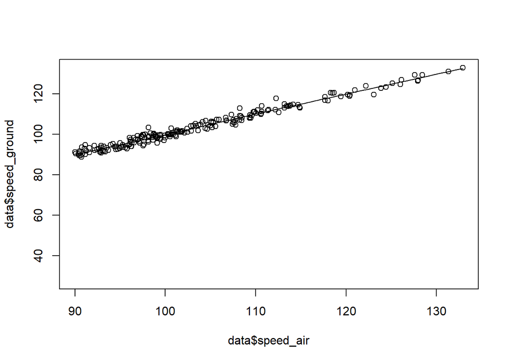

```r
scatter.smooth(data$speed_air,data$speed_ground)
```

```r
cor(data[which(is.na(data$speed_air)==FALSE),c(4,5)])
```

```
##              speed_ground speed_air
## speed_ground    1.0000000 0.9879355
## speed_air       0.9879355 1.0000000
```

Plotting the speed_air:

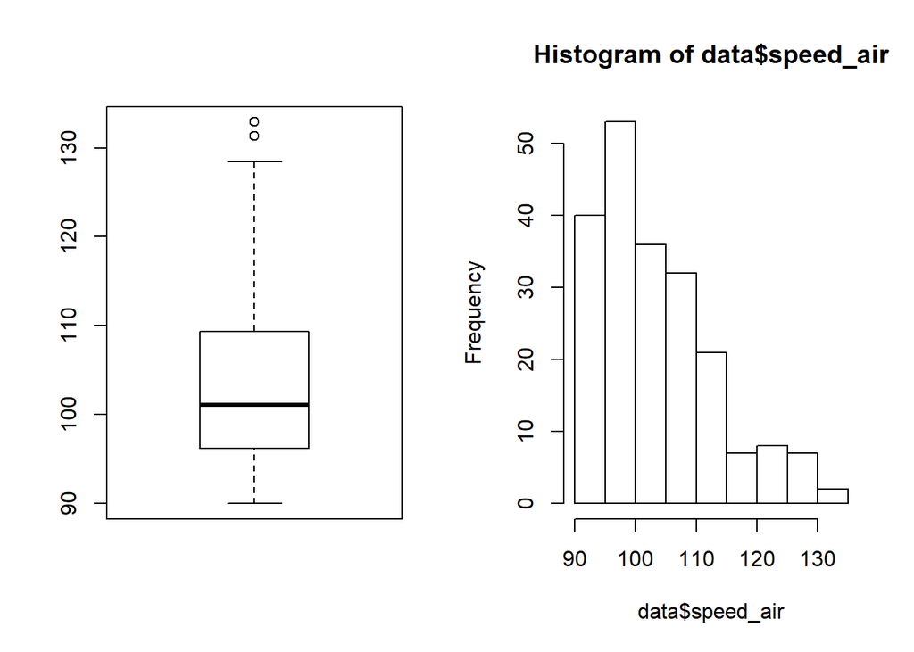

```r
par(mfrow=c(1,2))
boxplot(data$speed_air)
hist(data$speed_air)
```

The speed air does not have values below 90 -> speed_air has a truncated distribution. Hence, it is not a good idea to do imputation here.

## Data Exploration and Descriptive Analysis

In this chapter we will try to get a broader idea about the variables and their relation with the target feature. It will also help us form the significance order of the variables, which will help us while modeling.

#### **Analysis of variables and target feature**

[figure not shown]

```r
plot(data$distance~data$aircraft,xlab="distance",ylab="aircraft")
```

[figure not shown]

```r
plot(data$distance~data$duration,xlab="distance",ylab="duration")
```

[figure not shown]

```r
par(mfrow=c(3,2))
plot(data$distance~data$duration,col="blue",xlab="distance",ylab="duration")
plot(data$distance~data$no_pasg,col="blue",xlab="distance",ylab="no_pasg")
plot(data$distance~data$speed_ground,col="red",xlab="distance",ylab="speed_ground")
plot(data$distance~data$speed_air,col="red",xlab="distance",ylab="speed_air")
plot(data$distance~data$height,col="blue",xlab="distance",ylab="height")
plot(data$distance~data$pitch,col="blue",xlab="distance",ylab="pitch")
```

[figure not shown]

```r
par(mfrow=c(3,2))
hist(data$duration,
     main="Histogram for Duration",
     xlab="Duration",
     border="cadetblue2",
     col="cadetblue1",
     breaks=5)
hist(data$no_pasg,
     main="Histogram for Number of Passengers",
     xlab="no_pasg",
     border="cadetblue2",
     col="cadetblue1",
     breaks=5)
hist(data$duration,
     main="Histogram for Speed ground",
     xlab="speed_ground",
     border="cadetblue2",
     col="cadetblue1",
     breaks=5)
hist(data$speed_air,
     main="Histogram for speed_air",
     xlab="speed_air",
     border="cadetblue2",
     col="cadetblue1",
     breaks=5)
hist(data$height,
     main="Histogram for height",
     xlab="height",
     border="cadetblue2",
     col="cadetblue1",
     breaks=5)
hist(data$pitch,
     main="Histogram for pitch",
     xlab="pitch",
     border="cadetblue2",
     col="cadetblue1",
     breaks=5)
```

#### **Imputation**

```r
data<-data[,c(-5)]
data$duration <- ifelse(is.na(data$duration), mean(data$duration, na.rm=TRUE), data$duration)
sapply(data, function(x)sum(is.na(x)))
```

```
##     aircraft     duration      no_pasg speed_ground       height
##            0            0            0            0            0
##        pitch     distance
##            0            0
```

**Correlation**

```r
cor(data)
```

```
##                 aircraft     duration      no_pasg speed_ground
## aircraft      1.00000000 -0.044388844 -0.025197082 -0.045272747
## duration     -0.04438884  1.000000000 -0.028424904 -0.056848835
## no_pasg      -0.02519708 -0.028424904  1.000000000  0.002732399
## speed_ground -0.04527275 -0.056848835  0.002732399  1.000000000
## height       -0.01208114 -0.005107947  0.043540532 -0.045675516
## pitch         0.35694121 -0.042503608 -0.020602693 -0.039069885
## distance      0.23892711 -0.060380998 -0.020674628  0.861179571
##                    height       pitch    distance
## aircraft     -0.012081137  0.35694121  0.23892711
## duration     -0.005107947 -0.04250361 -0.06038100
## no_pasg       0.043540532 -0.02060269 -0.02067463
## speed_ground -0.045675516 -0.03906989  0.86117957
## height        1.000000000  0.02560274  0.10819867
## pitch         0.025602744  1.00000000  0.09237798
## distance      0.108198671  0.09237798  1.00000000
```

## Statistical Modeling

**Linear Regression**: A linear model for our case will be of the form Y = $b_0$ + $b_1$ $x_1$ + $b_2$ $x_2$…$b_n$ $x_n$ + ε. The constant $b_0$ is called the intercept and the coefficients $b_1$,.. $b_n$ are the parameter estimates for the variables $x_1$,$x_2$… $x_n$ respectively. The ε is the error term.

```r
model1<-(lm(distance~., data = data))

summary(model1)
```

```
##
## Call:
## lm(formula = distance ~ ., data = data)
##
## Residuals:
##     Min      1Q  Median      3Q     Max
## -685.04 -227.21  -94.26  121.91 1740.10
##
## Coefficients:
##                Estimate Std. Error t value Pr(>|t|)
## (Intercept)  -2.484e+03  1.617e+02 -15.358   <2e-16 ***
## aircraft      4.872e+02  2.648e+01  18.396   <2e-16 ***
## duration      5.654e-02  2.588e-01   0.218   0.8271
## no_pasg      -2.668e+00  1.650e+00  -1.617   0.1063
## speed_ground  4.192e+01  6.560e-01  63.900   <2e-16 ***
## height        1.393e+01  1.262e+00  11.039   <2e-16 ***
## pitch         4.404e+01  2.508e+01   1.756   0.0795 .
## ---
## Signif. codes:  0 '***' 0.001 '**' 0.01 '*' 0.05 '.' 0.1 ' ' 1
##
## Residual standard error: 356.8 on 831 degrees of freedom
## Multiple R-squared:  0.8431, Adjusted R-squared:  0.842
## F-statistic: 744.4 on 6 and 831 DF,  p-value: < 2.2e-16
```

The F-statistic comes less than 0.05 which means the model is significant. The adjusted R-squared of 0.84 suggests a strong model.

Our model should satisfy the following four criteria. 1)**bold**Linearity 2)**bold**Independent Errors 3)**bold**Normality assumption 4)**bold**Equal variance

Let’s see the model statistics.

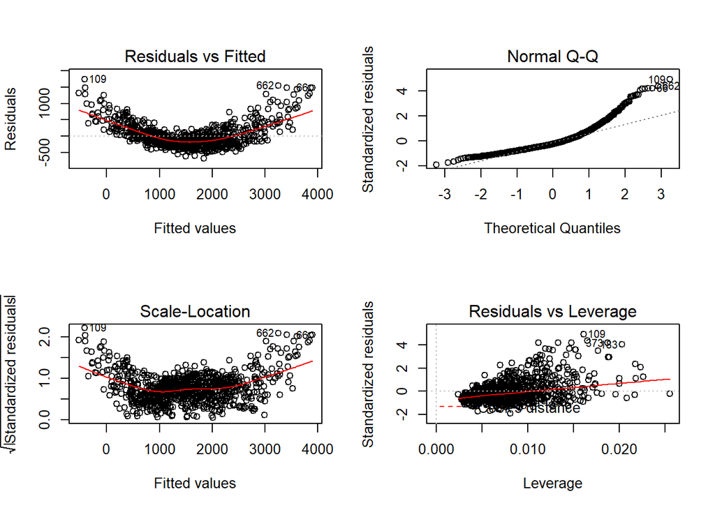

```r
par(mfrow = c(2, 2))
plot(model1)
```

The residual plot Fitted values vs Residuals have constant variance but it suggests non linearity. The QQ plot suggest right skewed distribution of the residuals.Observations 109,373 and 183 seem to be the three identifiable outliers.

Let’s do box cox transformation of y and see the model fit.

```r
bc <- MASS::boxcox(distance ~ ., data = data)
```

[figure not shown]

```r
(lambda <- bc$x[which.max(bc$y)])
```

```
## [1] 0.3434343
```

```r
data$distance <- (data$distance ^ lambda - 1) / lambda
model2<-lm(distance~.,data)
summary(model2)
```

```
##
## Call:
## lm(formula = distance ~ ., data = data)
##
## Residuals:
##     Min      1Q  Median      3Q     Max
## -9.0010 -1.4473 -0.2591  1.1195 14.2331
##
## Coefficients:
##               Estimate Std. Error t value Pr(>|t|)
## (Intercept)  -0.033277   1.030263  -0.032 0.974241
## aircraft      4.045490   0.168716  23.978  < 2e-16 ***
## duration     -0.001763   0.001649  -1.069 0.285225
## no_pasg      -0.025447   0.010513  -2.421 0.015709 *
## speed_ground  0.321077   0.004179  76.827  < 2e-16 ***
## height        0.134144   0.008038  16.688  < 2e-16 ***
## pitch         0.564036   0.159765   3.530 0.000438 ***
## ---
## Signif. codes:  0 '***' 0.001 '**' 0.01 '*' 0.05 '.' 0.1 ' ' 1
##
## Residual standard error: 2.273 on 831 degrees of freedom
## Multiple R-squared:  0.8892, Adjusted R-squared:  0.8884
## F-statistic:  1111 on 6 and 831 DF,  p-value: < 2.2e-16
```

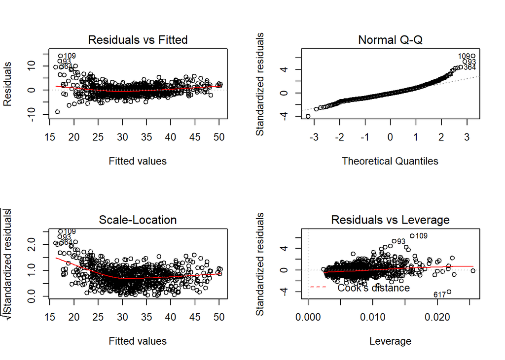

```r
par(mfrow=c(2,2))
plot(model2)
```

#### **Variable Selection**

We will try to use Stepwise regression to get out the best model.

```r
attach(data)
y<-distance
x1<-aircraft
x2<-duration
x3<-no_pasg
x4<-speed_ground
x5<-height
x6<-pitch
```

**Forward Selection**

```r
add1(lm(y~1,data=data), y~x1+x2+x3+x4+x5+x6, test="F")
```

|  | Df | Sum of Sq | RSS | AIC | F value | Pr(>F) |
| --- | --- | --- | --- | --- | --- | --- |
|  | NA | NA | 38732.809 | 3214.409 | NA | NA |
| x1 | 1 | 2846.52579 | 35886.284 | 3152.443 | 66.3121205 | 1.394342e-15 |
| x2 | 1 | 237.28672 | 38495.523 | 3211.260 | 5.1531110 | 2.345857e-02 |
| x3 | 1 | 24.56887 | 38708.241 | 3215.878 | 0.5306253 | 4.665481e-01 |
| x4 | 1 | 29154.18324 | 9578.626 | 2045.595 | 2544.5086448 | 7.412295e-256 |
| x5 | 1 | 858.80155 | 37874.008 | 3197.620 | 18.9564859 | 1.503126e-05 |
| x6 | 1 | 566.37306 | 38166.436 | 3204.065 | 12.4058708 | 4.511736e-04 |

```r
add1(lm(y~x1,data=data), y~x1+x2+x3+x4+x5+x6, test="F")
```

|  | Df | Sum of Sq | RSS | AIC | F value | Pr(>F) |
| --- | --- | --- | --- | --- | --- | --- |
|  | NA | NA | 35886.284 | 3152.443 | NA | NA |
| x2 | 1 | 170.26869 | 35716.015 | 3150.458 | 3.9806893 | 4.634929e-02 |
| x3 | 1 | 13.05746 | 35873.226 | 3154.138 | 0.3039308 | 5.815761e-01 |
| x4 | 1 | 30046.45114 | 5839.833 | 1632.926 | 4296.1483239 | 0.000000e+00 |
| x5 | 1 | 897.12620 | 34989.157 | 3133.228 | 21.4095002 | 4.298281e-06 |
| x6 | 1 | 25.90875 | 35860.375 | 3153.838 | 0.6032789 | 4.375497e-01 |

```r
add1(lm(y~x1+x4,data=data), y~x1+x2+x3+x4+x5+x6, test="F")
```

|  | Df | Sum of Sq | RSS | AIC | F value | Pr(>F) |
| --- | --- | --- | --- | --- | --- | --- |
|  | NA | NA | 5839.833 | 1632.926 | NA | NA |
| x2 | 1 | 8.012371 | 5831.820 | 1633.776 | 1.145837 | 2.847319e-01 |
| x3 | 1 | 15.130411 | 5824.702 | 1632.752 | 2.166422 | 1.414313e-01 |
| x5 | 1 | 1445.045535 | 4394.787 | 1396.697 | 274.226710 | 1.815649e-53 |
| x6 | 1 | 87.394827 | 5752.438 | 1622.290 | 12.670678 | 3.924369e-04 |

```r
add1(lm(y~x1+x4+x5,data=data), y~x1+x2+x3+x4+x5+x6, test="F")
```

|  | Df | Sum of Sq | RSS | AIC | F value | Pr(>F) |
| --- | --- | --- | --- | --- | --- | --- |
|  | NA | NA | 4394.787 | 1396.697 | NA | NA |
| x2 | 1 | 6.306514 | 4388.480 | 1397.494 | 1.197072 | 0.2742240058 |
| x3 | 1 | 30.733509 | 4364.053 | 1392.816 | 5.866338 | 0.0156456106 |
| x6 | 1 | 66.855844 | 4327.931 | 1385.851 | 12.867792 | 0.0003537772 |

```r
add1(lm(y~x1+x4+x5+x6,data=data), y~x1+x2+x3+x4+x5+x6, test="F")
```

|  | Df | Sum of Sq | RSS | AIC | F value | Pr(>F) |
| --- | --- | --- | --- | --- | --- | --- |
|  | NA | NA | 4327.931 | 1385.851 | NA | NA |
| x2 | 1 | 5.145466 | 4322.786 | 1386.854 | 0.9903401 | 0.31994861 |
| x3 | 1 | 29.504545 | 4298.427 | 1382.118 | 5.7108760 | 0.01708182 |

```r
add1(lm(y~x1+x4+x5+x6+x3,data=data), y~x1+x2+x3+x4+x5+x6, test="F")
```

|  | Df | Sum of Sq | RSS | AIC | F value | Pr(>F) |
| --- | --- | --- | --- | --- | --- | --- |
|  | NA | NA | 4298.427 | 1382.118 | NA | NA |
| x2 | 1 | 5.906711 | 4292.520 | 1382.966 | 1.143495 | 0.2852254 |

```r
model3<-lm(y~x1+x4+x5+x6+x3,data=data)
summary(model3)
```

```
##
## Call:
## lm(formula = y ~ x1 + x4 + x5 + x6 + x3, data = data)
##
## Residuals:
##     Min      1Q  Median      3Q     Max
## -9.0527 -1.4697 -0.2701  1.1592 14.2681
##
## Coefficients:
##              Estimate Std. Error t value Pr(>|t|)
## (Intercept) -0.371239   0.980674  -0.379 0.705115
## x1           4.051635   0.168633  24.026  < 2e-16 ***
## x4           0.321345   0.004172  77.023  < 2e-16 ***
## x5           0.134197   0.008039  16.694  < 2e-16 ***
## x6           0.569204   0.159706   3.564 0.000386 ***
## x3          -0.025114   0.010509  -2.390 0.017082 *
## ---
## Signif. codes:  0 '***' 0.001 '**' 0.01 '*' 0.05 '.' 0.1 ' ' 1
##
## Residual standard error: 2.273 on 832 degrees of freedom
## Multiple R-squared:  0.889,  Adjusted R-squared:  0.8884
## F-statistic:  1333 on 5 and 832 DF,  p-value: < 2.2e-16
```

The R square did not improve much.

Let’s Try **backward elimination**

```r
drop1(lm(y~x1+x2+x3+x4+x5+x6,data=data), test="F")
```

|  | Df | Sum of Sq | RSS | AIC | F value | Pr(>F) |
| --- | --- | --- | --- | --- | --- | --- |
|  | NA | NA | 4292.520 | 1382.966 | NA | NA |
| x1 | 1 | 2969.891749 | 7262.412 | 1821.618 | 574.949006 | 5.601420e-97 |
| x2 | 1 | 5.906711 | 4298.427 | 1382.118 | 1.143495 | 2.852254e-01 |
| x3 | 1 | 30.265789 | 4322.786 | 1386.854 | 5.859232 | 1.570896e-02 |
| x4 | 1 | 30489.098115 | 34781.618 | 3134.242 | 5902.463169 | 0.000000e+00 |
| x5 | 1 | 1438.572467 | 5731.092 | 1623.175 | 278.496956 | 3.845425e-54 |
| x6 | 1 | 64.381629 | 4356.902 | 1393.442 | 12.463806 | 4.377322e-04 |

It give the same results hence we will finalize model3

## Final Model

```r
final<-lm(distance~aircraft+no_pasg+speed_ground+height+pitch,data=data)
summary(final)
```

```
##
## Call:
## lm(formula = distance ~ aircraft + no_pasg + speed_ground + height +
##     pitch, data = data)
##
## Residuals:
##     Min      1Q  Median      3Q     Max
## -9.0527 -1.4697 -0.2701  1.1592 14.2681
##
## Coefficients:
##               Estimate Std. Error t value Pr(>|t|)
## (Intercept)  -0.371239   0.980674  -0.379 0.705115
## aircraft      4.051635   0.168633  24.026  < 2e-16 ***
## no_pasg      -0.025114   0.010509  -2.390 0.017082 *
## speed_ground  0.321345   0.004172  77.023  < 2e-16 ***
## height        0.134197   0.008039  16.694  < 2e-16 ***
## pitch         0.569204   0.159706   3.564 0.000386 ***
## ---
## Signif. codes:  0 '***' 0.001 '**' 0.01 '*' 0.05 '.' 0.1 ' ' 1
##
## Residual standard error: 2.273 on 832 degrees of freedom
## Multiple R-squared:  0.889,  Adjusted R-squared:  0.8884
## F-statistic:  1333 on 5 and 832 DF,  p-value: < 2.2e-16
```

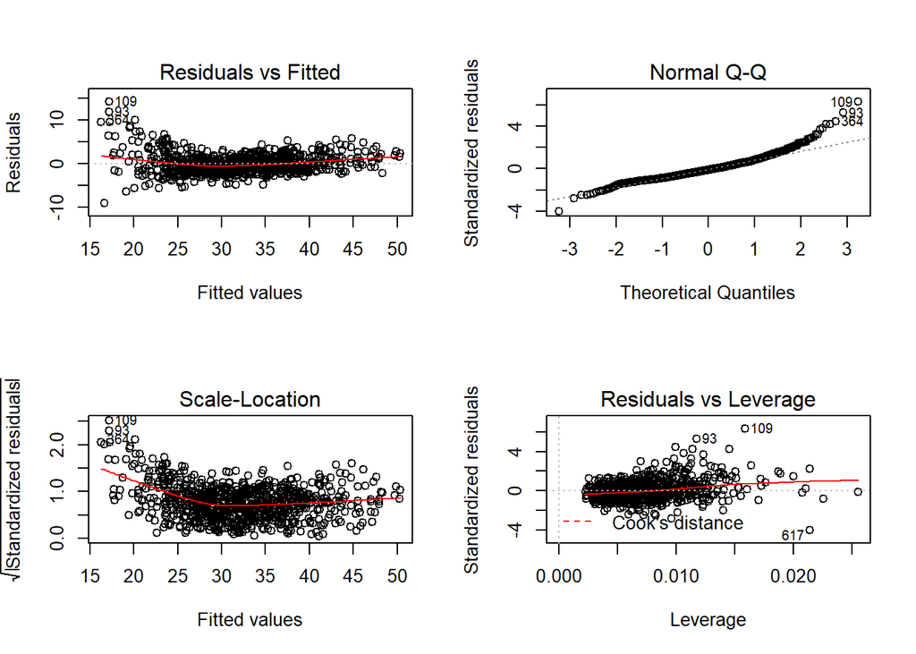

```r
par(mfrow=c(2,2))
plot(final)
```